# Notebook

### Chapter 5 ANOVA (Analysis of Variance)

Design of Experiments is a structured, organized method that is used to determine the relationship between the different explanatory variables affecting a response variable. The purpose of an experiment is to reveal how the response depends on other variables. In principle, experiments can give good evidence for causation. ANOVA (Analysis of Variance) is a statistical technique which is often used to analyze the data of an experimental design.

- To compare the means in 2 groups, we can use a t-test to test the equality of two population means.
- One-way ANOVA is an extension of the pooled t-test to 3 or more samples with the focus analysis on group differences.
- ANOVA is to compare the means of multiple independent groups.

The basic idea of ANOVA is that if the group means are truly similar, then the variability between group averages should be small relative to the natural variability among observations inside each group. On the other hand, if the group means are different, the between-group variability will tend to be large compared with the within-group variability. This comparison is summarized by the F statistic, which is the ratio of the mean square between groups to the mean square within groups. A large F value provides evidence against the null hypothesis that all group means are equal. In the most common form, one-way ANOVA, there is one categorical explanatory variable, called a factor, with several levels or groups. The response variable is quantitative.

For ANOVA results to be valid, several assumptions are usually made: the observations are independent, the response variable is approximately normally distributed within each group, and the population variances are approximately equal across groups. Even when normality is not exact, ANOVA is often fairly robust when sample sizes are moderate and balanced. If the ANOVA test is significant, it only tells us that not all means are equal; additional post hoc comparisons are usually needed to identify which specific groups differ.

An example: One of the many complications in the lives of persons who have Alzheimer's disease is that they tend to suffer from frequent periods of intense agitation. Some investigators have theorized that this agitation stems from old aversive conditionings—the conditioned fears and anxieties that a person accumulates over the course of his or her life—with which the Alzheimer's patient is no longer able to cope, on account of severely diminished cognitive capacities.

Against this background, a team of investigators has developed an experimental medication that they believe will substantially decrease the effects of old aversive conditionings. As a preliminary test of the medication, they trained 20 laboratory rats, by standard aversive conditioning procedures, to flee from a certain visual stimulus. These 20 subjects were then randomly and independently sorted into $a=4$ groups—A, B, C, and D—of 5 subjects each. In the subsequent experimental procedure, the members of each group received via subcutaneous injection one or another of four dosage levels of the medication. The members of group A, serving as a control group, received only an inert placebo containing zero units of the medication, while the members of groups B, C, and D received 1 unit, 2 units, and 3 units of the medication, respectively. Five minutes after receiving its injection, each subject was then presented with the aversively conditioned stimulus, and a measure was taken of how hard the subject pulled against a restraining harness in trying to move away from the stimulus. The smaller the pull, the smaller the degree of agitation presumed to be occasioned by the aversive stimulus.

The dosage data are:

| A | B | C | D |
| --- | --- | --- | --- |
| 27.0 | 22.8 | 21.9 | 23.5 |
| 26.2 | 23.1 | 23.4 | 19.6 |
| 28.8 | 27.7 | 20.1 | 23.7 |
| 33.5 | 27.6 | 27.8 | 20.8 |
| 28.8 | 24.0 | 19.3 | 23.9 |

Pleas reformat the data into the following before ANOVA:

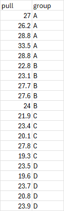

ANOVA is to test if the population means of different groups are the same or not.

Statistical model:

$$ y_{ij} = \mu_i + \epsilon_{ij}, \qquad i = 1,2,3,4, \qquad j = 1,2,\ldots,5 $$

where

- $y_{ij}$ is the $j$-th observation from the $i$-th group.
- $\mu_i$ is the population mean of the $i$-th group.
- $\epsilon_{ij} \sim iid\ N(0,\sigma^2)$ is the randomness for the $j$-th item of the $i$-th group.

$H_0: \mu_A = \mu_B = \mu_C = \mu_D $ (no effects due to the medication)

$H_1$: the population mean of at least one group is different.

If there is only one factor: dosage ( 0, 1, 2, 3) - 4 levels.

There are 4 groups, and 5 observations in each group.

### Standard One-Way ANOVA Table

| Source of Variation | Sum of Squares | Degrees of Freedom | Mean Square | F Statistic | p-value |
| --- | --- | --- | --- | --- | --- |
| Between Groups | $SSB$ | $k-1$ | $MSB=\dfrac{SSB}{k-1}$ | $F=\dfrac{MSB}{MSE}$ | p-value |
| Within Groups | $SSE$ | $N-k$ | $MSE=\dfrac{SSE}{N-k}$ |  |  |
| Total | $SST$ | $N-1$ |  |  |  |

where

$$ SST = SSB + SSW. $$

The assumptions of ANOVA:

1. The observations in each group are independent from each other.  
   How the experiment is conducted / how the data were collected.
2. Normality of the errors in the model

   ```
      QQ normal plot.

      Normality test.
   ```

3. Equal variances of different groups (The variances are the same for different groups)

   ```
      levene's test
   ```

```r
x = c(27.0,26.2,28.8,33.5,28.8,   22.8,23.1,27.7,27.6,24.0,  21.9,23.4,20.1,27.8,19.3, 23.5,19.6,23.7,20.8,23.9)
dosage = factor(rep(c("A","B","C","D"), each = 5))

#dosage

#x= c(27.0,22.8,21.9,23.5,26.2,23.1,23.4,19.6,28.8,27.7,20.1,23.7,33.5,27.6,27.8,20.8,28.8,24.0,19.3,23.9)
#dosage = c(rep("A",5), rep("B",5), rep("C", 5), rep("D",5))
#dat <- data.frame(y, group)
#model.tables(fit, type = "means")
```

```r
dat = data.frame(x, dosage)
#dat
```

```r
#ANOVA
fit = aov(x~dosage, data = dat)

summary(fit)
#To display the group means
model.tables(fit, type = "means")

#46.70/7.27
#p-value =  P( F with df1, df2 > F statistic)
```

```
            Df Sum Sq Mean Sq F value  Pr(>F)
dosage       3  140.1   46.70   6.423 0.00462 **
Residuals   16  116.3    7.27
---
Signif. codes:  0 ‘***’ 0.001 ‘**’ 0.01 ‘*’ 0.05 ‘.’ 0.1 ‘ ’ 1
```

```
Tables of means
Grand mean

24.675

 dosage
dosage
    A     B     C     D
28.86 25.04 22.50 22.30
```

The test statistics is F= 6.423. The p-value of ANOVA is 0.00462. Since P-value is below 0.05 (the default), reject H0. There is sufficient evidence that the medication has effects of old aversive conditionings.

Data visulization of ANOVA data ( one quantitative variable, one factor - a categrocal variable, a variable of several levels). Side by side box plots.

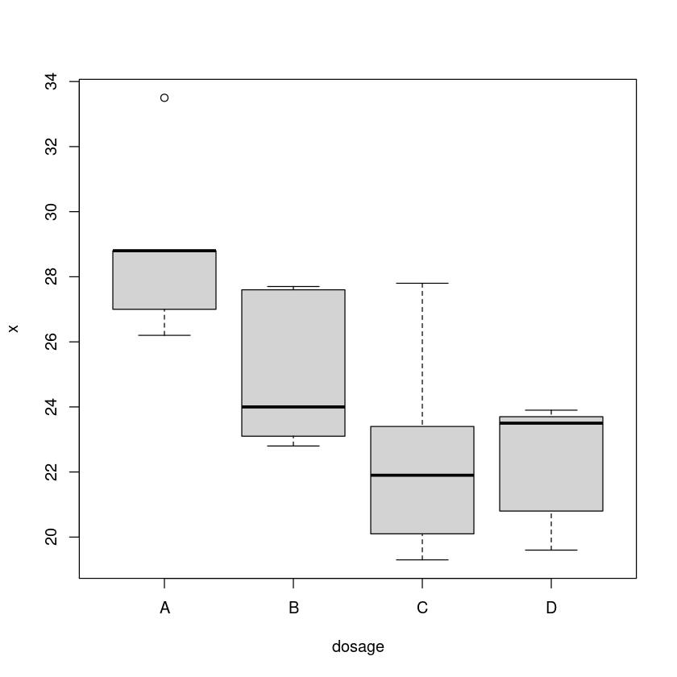

```r
boxplot(x~dosage)    #
```

```
	Shapiro-Wilk normality test

data:  resid1
W = 0.93034, p-value = 0.1568
```

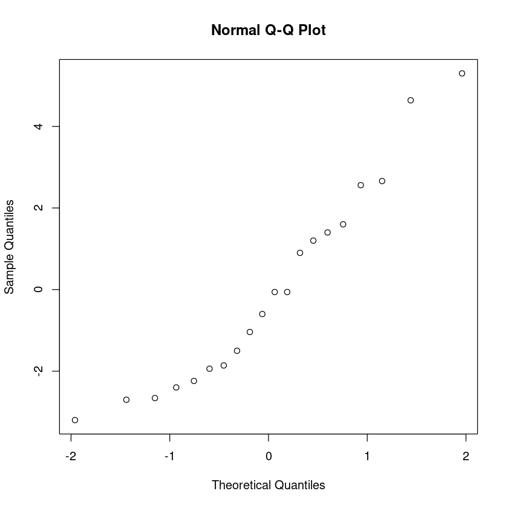

```r
#Check the normality of the error term
 resid1 = fit$residuals
 qqnorm(resid1)
#According to the QQ normal plot, it seems that the  error term are from a normal distribution.

#Shapiro-Wilk normality test
 shapiro.test(resid1)

#p-value is 0.1568. Fail to reject H0, and it is reasonable to assume that the error terms follow a normal distribuiton.
```

```r
#Equal variance assumption over different groups
#levene's test

library(car)

# levene.test(y, factor(x))
leveneTest(dat$x ~ factor(dat$dosage))

#The p-value is 0.8978917, which is above 0.1.
#There is no sufficient evidence the population variance of different groups are not the same.
#We can assume that the variances of these groups are the same.
```

A anova: 2 × 3

|  | Df <int> | F value <dbl> | Pr(>F) <dbl> |
| --- | --- | --- | --- |
| group | 3 | 0.1955403 | 0.8978917 |
|  | 16 | NA | NA |

### Post ANOVA analysis

Some post ANOVA procedures are to see how the poupulation means of different groups are different, when the null hypthosis is rejected. For the dosage example, if we would like to see how dosage groups are different, which group is different, ... we can run post anova analysis (multiple comparisons). If we reject $H_0$ in the ANOVA F-test, and suppose that we are interested in determining the specific differences between the means of the populations.

One of the procedure is Tukey Honestly Significant Differences. R code: TukeyHSD(fit)

```r
TukeyHSD(fit)

#B-A -3.82  -8.698941  1.058941 0.1546383,
#he confidence interval contain zero or p-value is above 0.05, there is no significant difference between dosage A and B.
#C-A -6.36 -11.238941 -1.481059 0.0088837
#The confidence interval is -11.238941 -1.481059, which is below zero,
#indicating the mean response in group C is significnatly lower than that of group A.
#p-value = 0.0088837, which is smaller than 0.05, reject H0. There is sufficient evidence
#that the population mean of the Group A is different to that of the Group C.

#Sort the groups by the means

means <- tapply(x, dosage, mean)

means
```

```
  Tukey multiple comparisons of means
    95% family-wise confidence level

Fit: aov(formula = x ~ dosage, data = dat)

$dosage
     diff        lwr       upr     p adj
B-A -3.82  -8.698941  1.058941 0.1546383
C-A -6.36 -11.238941 -1.481059 0.0088837
D-A -6.56 -11.438941 -1.681059 0.0069985
C-B -2.54  -7.418941  2.338941 0.4661560
D-B -2.74  -7.618941  2.138941 0.4026925
D-C -0.20  -5.078941  4.678941 0.9993976
```

**A**

28.86

**B**

25.04

**C**

22.5

**D**

22.3

Connected lines of different groups to show which groups are different to which according to the post anova anlsysis.

# Sort the groups by the means

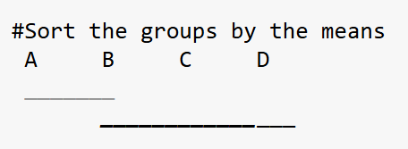

In Class problem: PlantGrowth is a built‑in R dataset containing results from a controlled experiment that measured how different treatments affect plant weight.

1. What is the statistical model?

Statistical model:

$$ y_{ij} = \mu_i + \epsilon_{ij}, \qquad i = 1,2,3, \qquad j = 1,2,\ldots,10 $$

where

- $y_{ij}$ is the $j$-th observation from the $i$-th group.
- $\mu_i$ is the population mean of the $i$-th group.
- $\epsilon_{ij} \sim iid\ N(0,\sigma^2)$ is the randomness for the $j$-th item of the $i$-th group.
2. Does the population mean plant weight differ significantly among the three treatment groups (control, trt1, trt2)? $H_0$: $\mu_1 = \mu_2 = \mu_3 $ (no effects due to the treatment) $H_1$: the population mean of at least one group is different.
3. Are ANOVA assumptions (normality and homogeneity of variance) satisfied for this dataset?
4. Which treatment groups differ from each other based on post‑ANOVA tests?
5. Test whether the control group (ctrl) differs from the average of trt1 and trt2.

A data.frame: 6 × 2

|  | weight <dbl> | group <fct> |
| --- | --- | --- |
| 1 | 4.17 | ctrl |
| 2 | 5.58 | ctrl |
| 3 | 5.18 | ctrl |
| 4 | 6.11 | ctrl |
| 5 | 4.50 | ctrl |
| 6 | 4.61 | ctrl |

```
            Df Sum Sq Mean Sq F value Pr(>F)
group        2  3.766  1.8832   4.846 0.0159 *
Residuals   27 10.492  0.3886
---
Signif. codes:  0 ‘***’ 0.001 ‘**’ 0.01 ‘*’ 0.05 ‘.’ 0.1 ‘ ’ 1
```

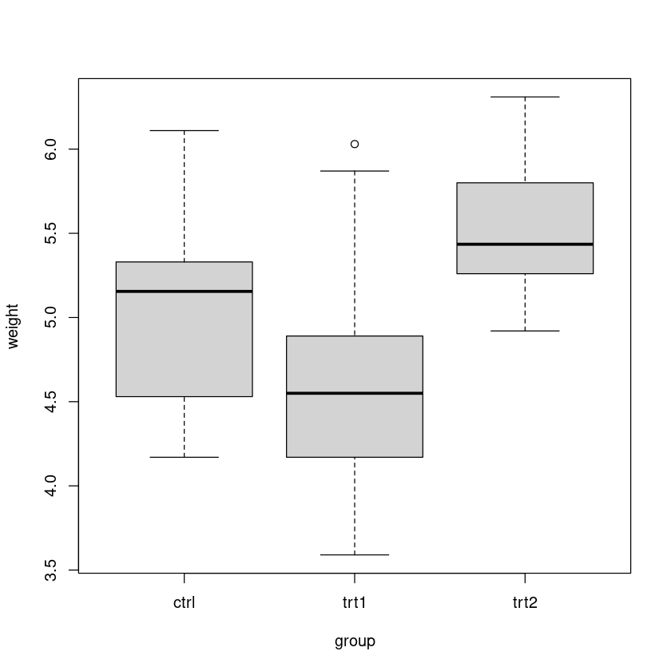

```
	Shapiro-Wilk normality test

data:  resid1
W = 0.96607, p-value = 0.4379
```

A anova: 2 × 3

|  | Df <int> | F value <dbl> | Pr(>F) <dbl> |
| --- | --- | --- | --- |
| group | 2 | 1.119186 | 0.3412266 |
|  | 27 | NA | NA |

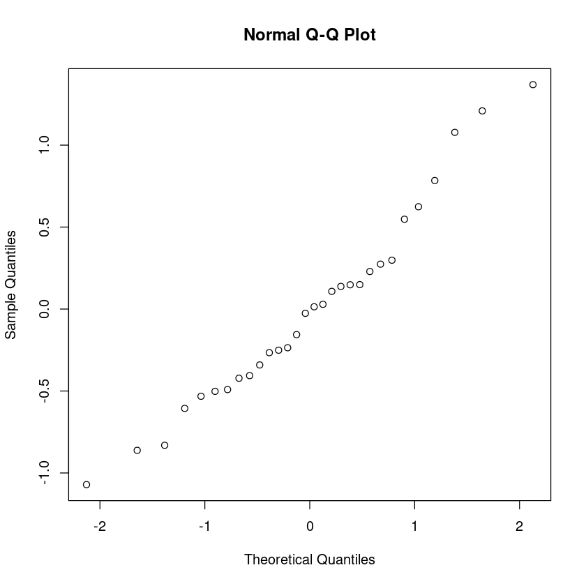

```r
data(PlantGrowth)
head(PlantGrowth)

fit = aov(weight~ group, data = PlantGrowth)
summary(fit)

#data visulization
boxplot(weight~ group, data = PlantGrowth)


#Check the assumptions
 resid1 = fit$residuals
 qqnorm(resid1)
#According to the QQ normal plot, it seems that the  error term are from a normal distribution.
#Shapiro-Wilk normality test
 shapiro.test(resid1)


library(car)
leveneTest(PlantGrowth$weight ~ factor(PlantGrowth$group))
```

### Pre-planned comparison (Contrast)

Before you have the data, there may be some specific questions. For examples, tell if the average effect of dosage B and D the same as the effect of dosage level C? We will need contrast.

In mathematical form, a contrast is a linear combination of group means:

$L = \sum_{i=1}^{k} c_i \mu_i$

where:

- $\mu_i$ = population mean of group $i$
- $c_i$ = contrast coefficients
- $k$ = number of groups

under the restriction of

$\sum_{i=1}^{k} c_i = 0$

The estimated Contrast ussing sample means $\bar{Y}_i$:

$\hat{L} = \sum_{i=1}^{k} c_i \bar{Y}_i$.

Example: suppose there are 4 groups (A, B, C and D). tell if the average effect of dosage B and D is the same as the effect of dosage level C. Write the contrast to answer the question.

k = 4,

$L = 0 \mu_A + 1 \mu_B - 2 \mu_C + 1 \mu_D $ <== > $( \mu_B + \mu_D)/2 = \mu_C$, if $L=0$.

0 + 1 - 2 + 1 = 0

$H_0: L = 0 $ vs $H_1: L \ne 0$.

Let MSE be the mean square error from ANOVA and $n_i$ the sample size for group $i$.

$SS_L = \frac{\left( \sum_{i=1}^{k} c_i \bar{Y}_i \right)^2}{\sum_{i=1}^{k} \frac{c_i^2}{n_i}}$

Test $H_0: L = 0$:

$F = \frac{SS_L}{\text{MSE}}$

with degrees of freedom:

- Numerator: $1$
- Denominator: $N - k$

```r
c.coef  = c(0, 1, -2, 1)
#The data

x = c(27.0,26.2,28.8,33.5,28.8,   22.8,23.1,27.7,27.6,24.0,  21.9,23.4,20.1,27.8,19.3, 23.5,19.6,23.7,20.8,23.9)
dosage = factor(rep(c("A","B","C","D"), each = 5))

dat = data.frame(x, factor(dosage))

head(dat)
```

A data.frame: 6 × 2

|  | x <dbl> | factor.dosage. <fct> |
| --- | --- | --- |
| 1 | 27.0 | A |
| 2 | 26.2 | A |
| 3 | 28.8 | A |
| 4 | 33.5 | A |
| 5 | 28.8 | A |
| 6 | 22.8 | B |

```r
means <- tapply(x, dosage, mean)

means
n =c(5,5,5,5)

SSL = (sum(c.coef*means))^2/( sum(c.coef^2/n) )
SSL

MSE =  7.27
Fc = SSL/MSE

Fc

p.value = 1 - pf(Fc, 1, 16)

p.value
```

**A**

28.86

**B**

25.04

**C**

22.5

**D**

22.3

4.563

0.627647867950481

0.439808462118892

P-value is 0.439. Fail to reject H0. There is no sufficient evidence that the average effect of dosage B and D is different than the effect of dosage level C.

```r
#To test a constrast not using the formula
fit = aov(x ~ dosage, data = dat)

 0.792^2
```

0.627264

```r
library(emmeans)

emm =  emmeans(fit, "dosage")

# pairwise comparisons
#contrast(emm, method = "pairwise")

# custom contrast
contrast(emm, list(BDvsC = c(0, 1, -2, 1)))
```

```
 contrast estimate   SE df t.ratio p.value
 BDvsC        2.34 2.95 16   0.792  0.4398
```

In class problem: tell if the average effect of dosage A, B and D is the same as the effect of dosage level C. Write the contrast to answer the question.

The contrast coefficients : c = (1, 1, -3, 1)

```r
library(emmeans)

emm =  emmeans(fit, "dosage")
# custom contrast
contrast(emm, list(ABDvsC = c(1, 1, -3, 1)))
```

```
 contrast estimate   SE df t.ratio p.value
 ABDvsC        8.7 4.18 16   2.083  0.0537
```

#### Linear effect and quardratic effects

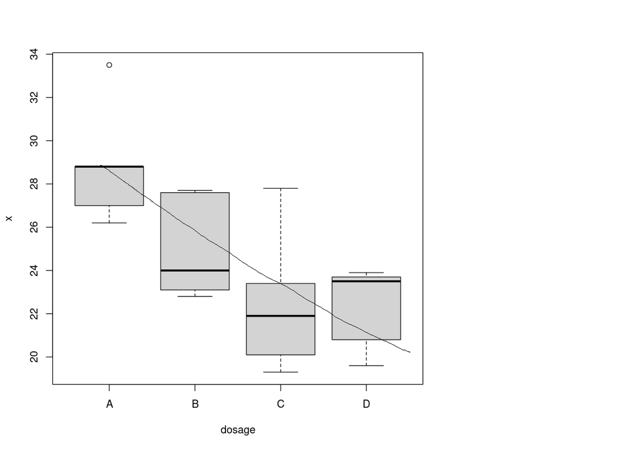

| Polynomial | 1 | 2 | 3 | Σaᵢ² |
| --- | --- | --- | --- | --- |
| Linear | -1 | 0 | 1 | 2 |
| Quadratic | 1 | -2 | 1 | 6 |

| Polynomial | 1 | 2 | 3 | 4 | Σaᵢ² |
| --- | --- | --- | --- | --- | --- |
| Linear | -3 | -1 | 1 | 3 | 20 |
| Quadratic | 1 | -1 | -1 | 1 | 4 |
| Cubic | -1 | 3 | -3 | 1 | 20 |

| Polynomial | 1 | 2 | 3 | 4 | 5 | Σaᵢ² |
| --- | --- | --- | --- | --- | --- | --- |
| Linear | -2 | -1 | 0 | 1 | 2 | 10 |
| Quadratic | 2 | -1 | -2 | -1 | 2 | 14 |
| Cubic | -1 | 2 | 0 | -2 | 1 | 10 |
| Quartic | 1 | -4 | 6 | -4 | 1 | 70 |

| Polynomial | 1 | 2 | 3 | 4 | 5 | 6 | Σaᵢ² |
| --- | --- | --- | --- | --- | --- | --- | --- |
| Linear | -5 | -3 | -1 | 1 | 3 | 5 | 70 |
| Quadratic | 5 | -1 | -4 | -4 | -1 | 5 | 84 |
| Cubic | -5 | 7 | 4 | -4 | -7 | 5 | 180 |
| Quartic | 1 | -3 | 2 | 2 | -3 | 1 | 28 |

| Polynomial | 1 | 2 | 3 | 4 | 5 | 6 | 7 | Σaᵢ² |
| --- | --- | --- | --- | --- | --- | --- | --- | --- |
| Linear | -3 | -2 | -1 | 0 | 1 | 2 | 3 | 28 |
| Quadratic | 5 | 0 | -3 | -4 | -3 | 0 | 5 | 84 |
| Cubic | -1 | 1 | 1 | 0 | -1 | -1 | 1 | 6 |
| Quartic | 3 | -7 | 1 | 6 | 1 | -7 | 3 | 154 |

Example: using the dosage data (A, B, C, D) in the previous example. Run a contrast to see if there is some linear effects due to the dosage.

The linear contrast coefficients = -3 -1 1 3

$L= -3 \mu_A - 1 \mu_B + \mu_C + 3 \mu_D$

$H_0: L = 0$

Example: using the dosage data (A, B, C, D) in the previous example. Run a contrast to see if there is some quardratic effects due to the dosage.

```r
#emm =  emmeans(fit, "dosage")
# custom contrast
contrast(emm, list(Linear = c(-3, -1, 1, 3)))
```

```
 contrast estimate   SE df t.ratio p.value
 Linear      -22.2 5.39 16  -4.120  0.0008
```

The p-value for the linear constrast is 0.0008. Reject H0. There is sufficient evidence that there is a linear effect due to the dosage level.

```r
contrast(emm, list(Linear = c(1, -1, -1, 1)))
```

```
 contrast estimate   SE df t.ratio p.value
 Linear       3.62 2.41 16   1.501  0.1528
```

The p-value for the quardratic constrast is 0.1528. Fail to reject H0. There is no sufficient evidence that there is a quaratic effect due to the dosage level.

In Class problem: PlantGrowth is a built‑in R dataset containing results from a controlled experiment that measured how different treatments affect plant weight.

c. Which treatment groups differ from each other based on post‑ANOVA tests?

d. Test whether the mean weight of the control group (ctrl) differs from the average weight of both trt1 and trt2 groups.

A data.frame: 6 × 2

|  | weight <dbl> | group <fct> |
| --- | --- | --- |
| 1 | 4.17 | ctrl |
| 2 | 5.58 | ctrl |
| 3 | 5.18 | ctrl |
| 4 | 6.11 | ctrl |
| 5 | 4.50 | ctrl |
| 6 | 4.61 | ctrl |

```
            Df Sum Sq Mean Sq F value Pr(>F)
group        2  3.766  1.8832   4.846 0.0159 *
Residuals   27 10.492  0.3886
---
Signif. codes:  0 ‘***’ 0.001 ‘**’ 0.01 ‘*’ 0.05 ‘.’ 0.1 ‘ ’ 1
```

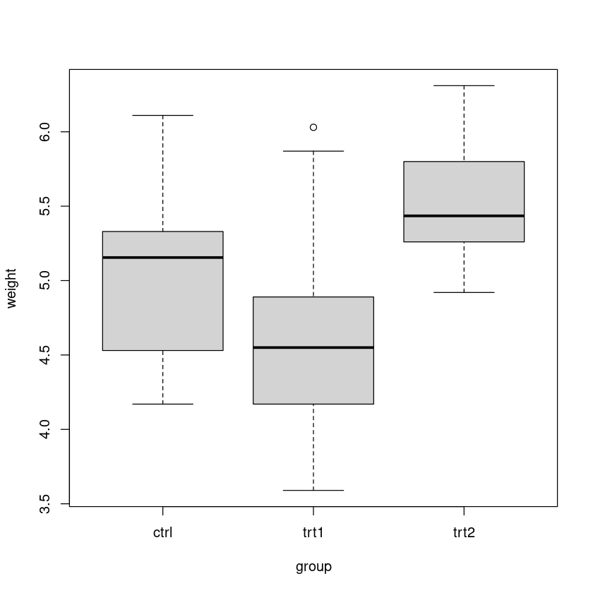

```r
data(PlantGrowth)
head(PlantGrowth)

fit = aov(weight~ group, data = PlantGrowth)
summary(fit)

#data visulization
boxplot(weight~ group, data = PlantGrowth)

#Post anova, H0 is rejected.
```

```r
TukeyHSD(fit)

means <- tapply(PlantGrowth$weight, PlantGrowth$group, mean)

means
```

```
  Tukey multiple comparisons of means
    95% family-wise confidence level

Fit: aov(formula = weight ~ group, data = PlantGrowth)

$group
            diff        lwr       upr     p adj
trt1-ctrl -0.371 -1.0622161 0.3202161 0.3908711
trt2-ctrl  0.494 -0.1972161 1.1852161 0.1979960
trt2-trt1  0.865  0.1737839 1.5562161 0.0120064
```

**ctrl**

5.032

**trt1**

4.661

**trt2**

5.526

```r
library(emmeans)

emm =  emmeans(fit, "group")
# custom contrast
contrast(emm, list(ABDvsC = c(2, -1, -1)))
```

```
 contrast estimate    SE df t.ratio p.value
 ABDvsC     -0.123 0.483 27  -0.255  0.8009
```

P-value is 0.80. There is no sufficient evidence that the mean weight of the control group (ctrl) is different from the average weight of both trt1 and trt2 groups.